# ML Assignment #1

## Question 2: Diabetes Prediction

This is a Jupyter Notebook created for the analysis on the given dataset for the question 2 in ML assignment #1. The assignment is done collaborately by the group of 4 members. The details are as follows,

Group ID : `ML_GROUP006`

Group Members:

```
1. Poornima J : 2018AC04550
2. Bala Kavin Pon : 2018AC04531
3. Venkataramanan Krishnan : 2018AC04529
4. Ponvani : 2018AC04559
```

### Problem Statement 2

Consider the diabetes data (diabetes.csv) has a response variable of whether a person is having diabetes, which is given by a 1.

- Import the dataset from https://www.kaggle.com/uciml/pima-indians-diabetes-database (1 points).
- Extract X as all columns except the last column and Y as last column. (1 points)
- Visualize the dataset using any two appropriate plots. (2 points)
- Split the data into training set and testing set. (1 points)
- Train a Logistic regression model for the dataset. (1 points)
- Display the coefficients and form the logistic regression equation. (1 point)
- Compute the accuracy and confusion matrix. (2 points)
- Plot the decision boundary. (1 point)
- Identify which of the following variables are positively associated with the target column. (1 point)
- For a woman aged 35 and mother of 2 children, predict and display the class, if her bmi was 35 instead of 24 according to the model? (2 points).

## 0. Import Libraries

```python
import pandas as pd
from sklearn.model_selection import train_test_split
from sklearn.linear_model import LogisticRegression
import seaborn as sns
import matplotlib.pyplot as plt
from sklearn.metrics import classification_report
from sklearn import metrics
from sklearn.metrics import roc_auc_score
from sklearn.metrics import roc_curve
import numpy as np
from sklearn.externals import joblib
```

## 1. Loading the dataset

```python
data = pd.read_csv(filepath_or_buffer='./diabetes.csv')
```

```python
data.head()
data.describe()
```

|  | Pregnancies | Glucose | BloodPressure | SkinThickness | Insulin | BMI | DiabetesPedigreeFunction | Age | Outcome |
| --- | --- | --- | --- | --- | --- | --- | --- | --- | --- |
| count | 768.000000 | 768.000000 | 768.000000 | 768.000000 | 768.000000 | 768.000000 | 768.000000 | 768.000000 | 768.000000 |
| mean | 3.845052 | 120.894531 | 69.105469 | 20.536458 | 79.799479 | 31.992578 | 0.471876 | 33.240885 | 0.348958 |
| std | 3.369578 | 31.972618 | 19.355807 | 15.952218 | 115.244002 | 7.884160 | 0.331329 | 11.760232 | 0.476951 |
| min | 0.000000 | 0.000000 | 0.000000 | 0.000000 | 0.000000 | 0.000000 | 0.078000 | 21.000000 | 0.000000 |
| 25% | 1.000000 | 99.000000 | 62.000000 | 0.000000 | 0.000000 | 27.300000 | 0.243750 | 24.000000 | 0.000000 |
| 50% | 3.000000 | 117.000000 | 72.000000 | 23.000000 | 30.500000 | 32.000000 | 0.372500 | 29.000000 | 0.000000 |
| 75% | 6.000000 | 140.250000 | 80.000000 | 32.000000 | 127.250000 | 36.600000 | 0.626250 | 41.000000 | 1.000000 |
| max | 17.000000 | 199.000000 | 122.000000 | 99.000000 | 846.000000 | 67.100000 | 2.420000 | 81.000000 | 1.000000 |

## 2. Extract X as all columns except the last column and Y as last column

```python
#y = data.Outcome
#x = data.drop('Outcome',axis=1)
X = data[data.columns[0:8]]
y = data[data.columns[8:9]]
```

```python
X.head()
```

|  | Pregnancies | Glucose | BloodPressure | SkinThickness | Insulin | BMI | DiabetesPedigreeFunction | Age |
| --- | --- | --- | --- | --- | --- | --- | --- | --- |
| 0 | 6 | 148 | 72 | 35 | 0 | 33.6 | 0.627 | 50 |
| 1 | 1 | 85 | 66 | 29 | 0 | 26.6 | 0.351 | 31 |
| 2 | 8 | 183 | 64 | 0 | 0 | 23.3 | 0.672 | 32 |
| 3 | 1 | 89 | 66 | 23 | 94 | 28.1 | 0.167 | 21 |
| 4 | 0 | 137 | 40 | 35 | 168 | 43.1 | 2.288 | 33 |

```python
y.head()
```

|  | Outcome |
| --- | --- |
| 0 | 1 |
| 1 | 0 |
| 2 | 1 |
| 3 | 0 |
| 4 | 1 |

## 3. Visualize the dataset

```python
#Getting the number of diabetic (1) and Non Diabetic (0) women.
data['Outcome'].value_counts()
count_no_sub = len(data[data['Outcome']==0])
count_sub = len(data[data['Outcome']==1])
pct_of_no_sub = count_no_sub/(count_no_sub+count_sub)
print("percentage of not Diabetic", pct_of_no_sub*100)
pct_of_sub = count_sub/(count_no_sub+count_sub)
print("percentage of Diabetic", pct_of_sub*100)
```

```
percentage of not Diabetic 65.10416666666666
percentage of Diabetic 34.89583333333333
```

```python
data.groupby('Outcome').mean()
```

| Outcome | Pregnancies | Glucose | BloodPressure | SkinThickness | Insulin | BMI | DiabetesPedigreeFunction | Age |
| --- | --- | --- | --- | --- | --- | --- | --- | --- |
| 0 | 3.298000 | 109.980000 | 68.184000 | 19.664000 | 68.792000 | 30.304200 | 0.429734 | 31.190000 |
| 1 | 4.865672 | 141.257463 | 70.824627 | 22.164179 | 100.335821 | 35.142537 | 0.550500 | 37.067164 |

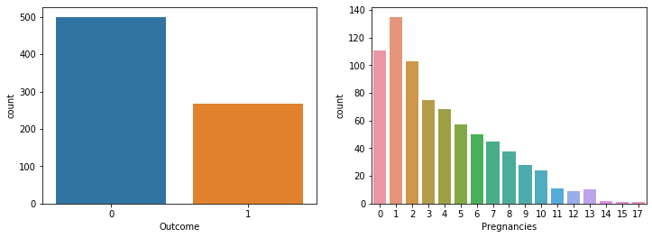

```python
#Plotting the number of diabetic (1) and Non Diabetic (0) women.
#Plotting number of pregnancies
_, axes = plt.subplots(nrows=1, ncols=2, figsize=(12, 4))
sns.countplot(x='Outcome', data=data, ax=axes[0]);
sns.countplot(x='Pregnancies', data=data, ax=axes[1]);
```

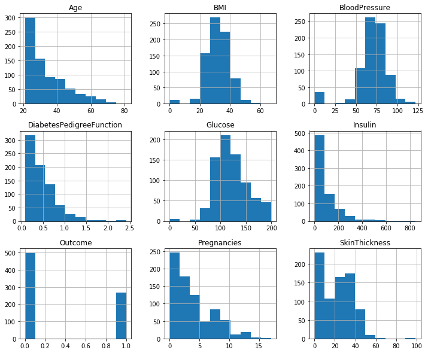

```python
#Plots of all the variables
data.hist(figsize=(12, 10))

plt.show()
```

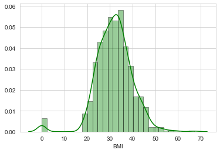

```python
# BMI plot
sns.set_style('whitegrid')
#sns.countplot(x='Outcome', hue='Age', data=data)
sns.distplot(data['BMI'], kde=True, bins=30, color='Green',
            hist_kws={'edgecolor':'black'})
```

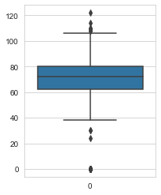

```python
#BP plot
_, ax = plt.subplots(figsize=(3, 4))
sns.boxplot(data=data['BloodPressure'], ax=ax);
```

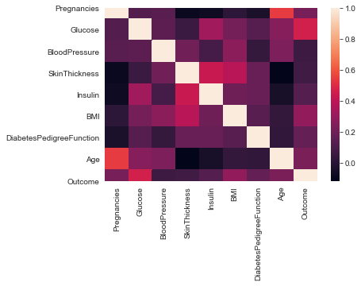

```python
#look at the correlations among the numerical variables in our dataset.
#This information is important to know as logistic regression does not handle highly correlated input variables well
#brighter colors indicate more correlation
corr_matrix = data.corr()
sns.heatmap(corr_matrix);
```

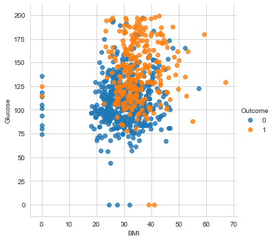

```python
# Plot of BMI vs Glocose with Outcomes highlighted
sns.lmplot('BMI', 'Glucose', data=data,
           hue='Outcome', fit_reg=False);
```

## 4. Split the data into training set and testing set

```python
X_train,X_test,y_train,y_test = train_test_split(X,y,test_size=0.25)
X_train.head()
```

|  | Pregnancies | Glucose | BloodPressure | SkinThickness | Insulin | BMI | DiabetesPedigreeFunction | Age |
| --- | --- | --- | --- | --- | --- | --- | --- | --- |
| 613 | 6 | 105 | 80 | 28 | 0 | 32.5 | 0.878 | 26 |
| 651 | 1 | 117 | 60 | 23 | 106 | 33.8 | 0.466 | 27 |
| 163 | 2 | 100 | 64 | 23 | 0 | 29.7 | 0.368 | 21 |
| 704 | 4 | 110 | 76 | 20 | 100 | 28.4 | 0.118 | 27 |
| 677 | 0 | 93 | 60 | 0 | 0 | 35.3 | 0.263 | 25 |

**Normalise the data. This impacts the results**

```python
means = np.mean(X_train, axis=0)
stds = np.std(X_train, axis=0)
X_train = (X_train - means)/stds
X_test = (X_test - means)/stds
```

## 5. Logistic regression

```python
lm = LogisticRegression()
lm.fit(X_train,y_train)
y_pred=lm.predict(X_test)
print(classification_report(y_test,y_pred))
```

```
              precision    recall  f1-score   support

           0       0.79      0.86      0.82       125
           1       0.69      0.57      0.62        67

    accuracy                           0.76       192
   macro avg       0.74      0.72      0.72       192
weighted avg       0.75      0.76      0.75       192
```

## 6. Display the coefficients and form the logistic regression equation

```python
df_coefs = pd.DataFrame(lm.coef_[0], index=X.columns, columns = ['Coefficient'])
df_coefs
```

|  | Coefficient |
| --- | --- |
| Pregnancies | 0.344636 |
| Glucose | 1.217841 |
| BloodPressure | -0.224790 |
| SkinThickness | -0.101913 |
| Insulin | -0.179695 |
| BMI | 0.795609 |
| DiabetesPedigreeFunction | 0.310736 |
| Age | 0.128827 |

## 7. Compute the accuracy and confusion matrix.

```python
cnf_matrix = metrics.confusion_matrix(y_test, y_pred)
print(cnf_matrix)

print('True positive = ', cnf_matrix[0][0])
print('False positive = ', cnf_matrix[0][1])
print('False negative = ', cnf_matrix[1][0])
print('True negative = ', cnf_matrix[1][1])
print("Accuracy:",metrics.accuracy_score(y_test, y_pred))
print("Precision:",metrics.precision_score(y_test, y_pred))
print("Recall:",metrics.recall_score(y_test, y_pred))
```

```
[[108  17]
 [ 29  38]]
True positive =  108
False positive =  17
False negative =  29
True negative =  38
Accuracy: 0.7604166666666666
Precision: 0.6909090909090909
Recall: 0.5671641791044776
```

**ROC Curve**

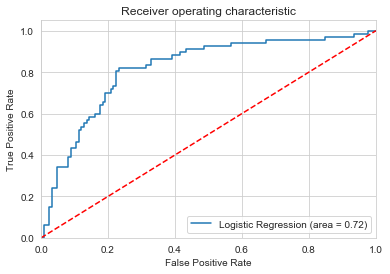

```python
logit_roc_auc = roc_auc_score(y_test, lm.predict(X_test))
fpr, tpr, thresholds = roc_curve(y_test, lm.predict_proba(X_test)[:,1])
plt.figure()
plt.plot(fpr, tpr, label='Logistic Regression (area = %0.2f)' % logit_roc_auc)
plt.plot([0, 1], [0, 1],'r--')
plt.xlim([0.0, 1.0])
plt.ylim([0.0, 1.05])
plt.xlabel('False Positive Rate')
plt.ylabel('True Positive Rate')
plt.title('Receiver operating characteristic')
plt.legend(loc="lower right")
plt.savefig('Log_ROC')
plt.show()
```

## 8. Plot the decision boundary.

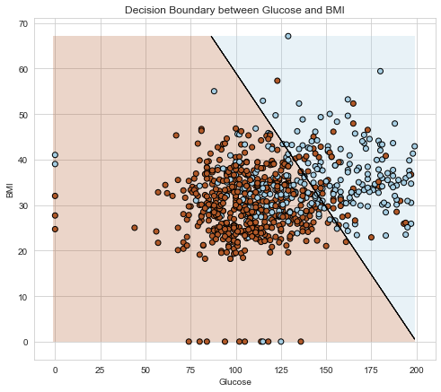

```python
X = data[['Glucose', 'BMI']]
Y = data['Outcome']

logreg = LogisticRegression()
logreg.fit(X, Y)

x_min, x_max = X['Glucose'].min()-1, X['Glucose'].max()
y_min, y_max = X['BMI'].min(), X['BMI'].max()
h = .02  # step size in the mesh
xx, yy = np.meshgrid(np.arange(x_min, x_max, h), np.arange(y_min, y_max, h))
Z = logreg.predict(np.c_[xx.ravel(), yy.ravel()])

# Put the result into a color plot
Z = Z.reshape(xx.shape)
plt.figure(figsize=(8,7))
plt.contourf(xx, yy, Z, cmap='Paired_r', alpha=0.25)
plt.contour(xx, yy, Z, colors='k', linewidths=0.7)
plt.scatter(X['Glucose'], X['BMI'], c=Y, cmap='Paired_r', edgecolors='k')
plt.xlabel('Glucose')
plt.ylabel('BMI')
plt.title('Decision Boundary between Glucose and BMI')
plt.show()
```

## 9. Identify which of the following variables are positively associated with the target column.

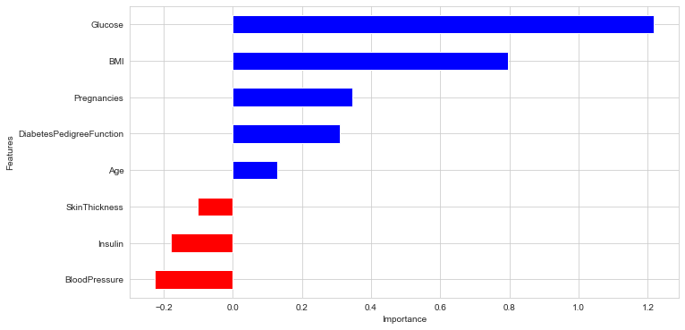

```python
coeff = list(lm.coef_[0])
labels = list(X_train.columns)
features = pd.DataFrame()
features['Features'] = labels
features['importance'] = coeff
features.sort_values(by=['importance'], ascending=True, inplace=True)
features['positive'] = features['importance'] > 0
features.set_index('Features', inplace=True)
features.importance.plot(kind='barh', figsize=(11, 6),color = features.positive.map({True: 'blue', False: 'red'}))
plt.xlabel('Importance')
```

**Glucose,BMI,Pregnancies,Diabetes Pedigree function,Age positively impact the outcome . Insulin and BP have negative impact**

## 10. For a woman aged 35 and mother of 2 children, predict and display the class, if her bmi was 35 instead of 24 according to the model?

```python
sampledata = {'Pregnancies':[2,2],'Glucose':[0,0],'BloodPressure':[0,0],'SkinThickness':[0,0],'Insulin':[0,0],'BMI':[35,24],'DiabetesPedigreeFunction':[0,0],'Age':[35,35]}

df = pd.DataFrame(sampledata)
df
```

|  | Pregnancies | Glucose | BloodPressure | SkinThickness | Insulin | BMI | DiabetesPedigreeFunction | Age |
| --- | --- | --- | --- | --- | --- | --- | --- | --- |
| 0 | 2 | 0 | 0 | 0 | 0 | 35 | 0 | 35 |
| 1 | 2 | 0 | 0 | 0 | 0 | 24 | 0 | 35 |

```python
predictionProbability = lm.predict_proba(df)
prediction = lm.predict(df)
print('Probability:', predictionProbability)
print('prediction:', prediction)
```

```
Probability: [[1.06581410e-14 1.00000000e+00]
 [6.71986911e-11 1.00000000e+00]]
prediction: [1 1]
```

It is predicted that **35 year old woman with 2 children** with **BMI 35** will be **Diabetic.**

It is predicted that **35 year old woman with 2 children** with **BMI 24** will also be **Diabetic.**